# ARIMAX/SARIMAX Model for S&P 500 index and macroeconomic factors

Endogenous variable: S&P 500 Index Exogenous variables: Macroeconomic indicators such as GDP, inflation rate, unemployment rate and interest rates

Before proceeding with model selection, it can be useful to examine the feature variables and select the appropriate ones. This can be done by creating cross-correlation function plots, which can serve as a verification of the correlation heatmap for the variables.

##### CCF Plot for S&P 500 Index and Exogenous Variables

**GDP**

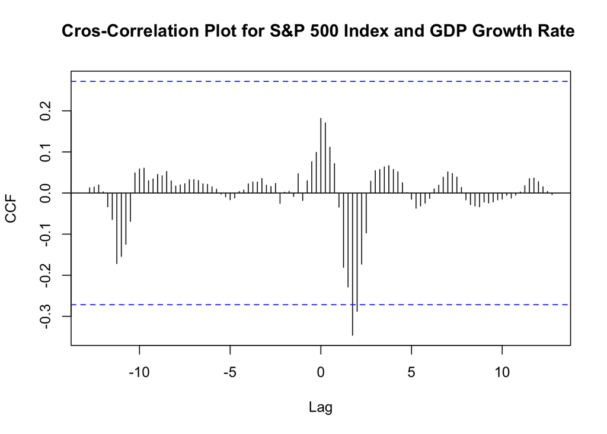

```r
par(mfrow=c(1,1))
ccf_result <- ccf(normalized_index_factor_data[, c("GSPC.Adjusted")], normalized_index_factor_data[, c("gdp")],
    lag.max = 300,
    main = "Cros-Correlation Plot for S&P 500 Index and GDP Growth Rate ",
    ylab = "CCF")
```

```r
cat("The sum of cross correlation function is", sum(abs(ccf_result$acf)))
```

```
The sum of cross correlation function is 4.829354
```

**Interest Rate**

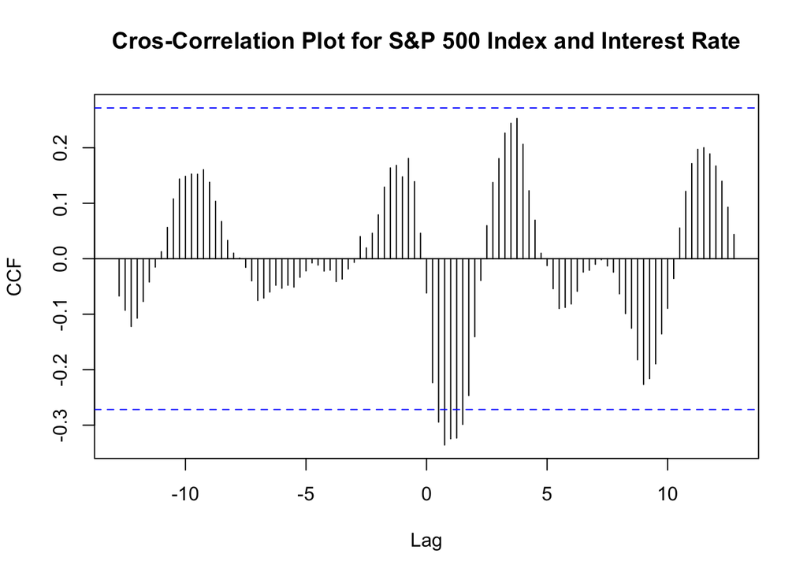

```r
par(mfrow=c(1,1))
ccf_result <- ccf(normalized_index_factor_data[, c("GSPC.Adjusted")], normalized_index_factor_data[, c("interest")],
    lag.max = 300,
    main = "Cros-Correlation Plot for S&P 500 Index and Interest Rate",
    ylab = "CCF")
```

```r
cat("The sum of cross correlation function is", sum(abs(ccf_result$acf)))
```

```
The sum of cross correlation function is 10.66717
```

**Inflation Rate**

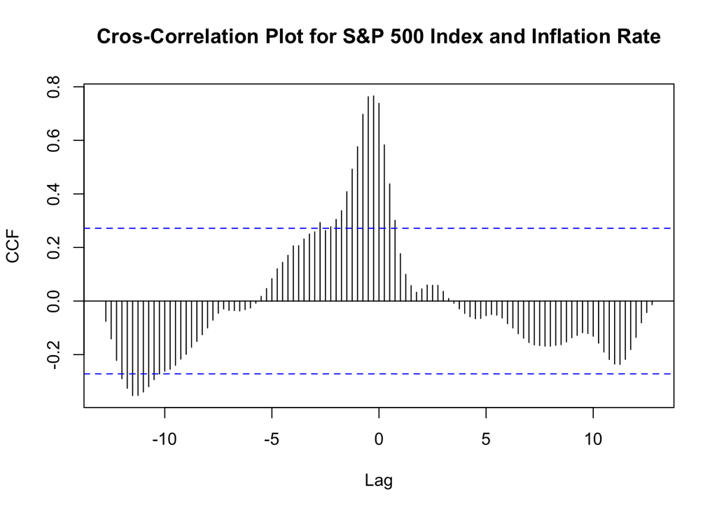

```r
par(mfrow=c(1,1))
ccf_result <- ccf(normalized_index_factor_data[, c("GSPC.Adjusted")], normalized_index_factor_data[, c("inflation")],
    lag.max = 300,
    main = "Cros-Correlation Plot for S&P 500 Index and Inflation Rate",
    ylab = "CCF")
```

```r
cat("The sum of cross correlation function is", sum(abs(ccf_result$acf)))
```

```
The sum of cross correlation function is 19.21394
```

**Unemployment Rate**

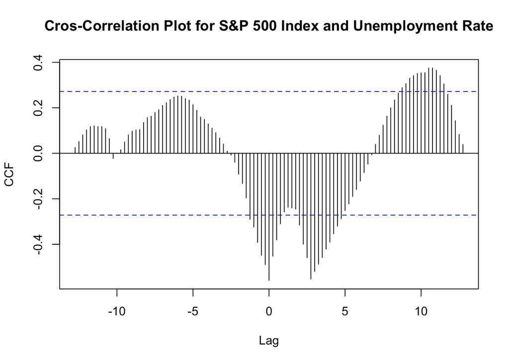

```r
par(mfrow=c(1,1))
ccf_result <- ccf(normalized_index_factor_data[, c("GSPC.Adjusted")], normalized_index_factor_data[, c("unemployment")],
    lag.max = 300,
    main = "Cros-Correlation Plot for S&P 500 Index and Unemployment Rate",
    ylab = "CCF")
```

```r
cat("The sum of cross correlation function is", sum(abs(ccf_result$acf)))
```

```
The sum of cross correlation function is 22.33667
```

The cross-correlation feature plots reaffirm the findings from the heatmap analysis, indicating that inflation and unemployment rate exhibit stronger correlations with the index compared to GDP and interest rates. The cross-correlation plots for GDP and interest rates show weaker and more scattered patterns, with strikes between the blue lines indicating lower correlation coefficients. This suggests that inflation and unemployment rate are more suitable feature variables for the ARIMAX model when predicting S&P 500 movements.

Final Exogenous variables: Macroeconomic indicators: Inflation rate and unemployment rate.

##### Endogenous and Exogenous Variables Plot

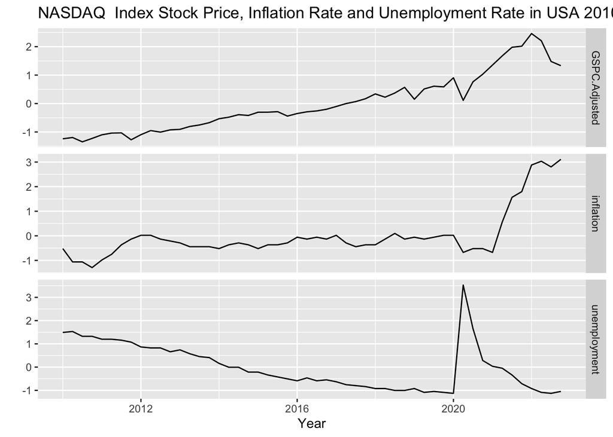

```r
final_sp500_factor_data <- index_factor_data %>%dplyr::select( Date,GSPC.Adjusted, inflation,unemployment)
numeric_vars_sp500_factor_data <- c("GSPC.Adjusted", "inflation", "unemployment")
numeric_sp500_factor_data <- final_sp500_factor_data[, numeric_vars_sp500_factor_data]
normalized_sp500_factor_data_numeric <- scale(numeric_sp500_factor_data)
normalized_sp500_factor_data_numeric_df <- data.frame(normalized_sp500_factor_data_numeric)
normalized_sp500_factor_data_ts <- ts(normalized_sp500_factor_data_numeric, start = c(2010, 1), frequency = 4)

autoplot(normalized_sp500_factor_data_ts, facets=TRUE) +
  xlab("Year") + ylab("") +
  ggtitle("NASDAQ  Index Stock Price, Inflation Rate and Unemployment Rate in USA 2010-2023")
```

##### Check the stationarity

Before proceeding with further analysis, it’s important to check the stationarity of the time series data. If the series is not stationary, it needs to be differentiated before performing a ARIMAX model. The stationarity of a multivariate time series data can be checked using the Phillips-Perron test, which is specifically designed for multivariate data. By performing the Phillips-Perron test on the multivariate time series data, we can determine if the data is stationary or if it requires differencing to make it suitable for ARIMAX modeling.

```r
# Convert your multivariate time series data to a matrix
final_sp500_factor_data_ts_multivariate <- as.matrix(normalized_sp500_factor_data_ts)

# Check for stationarity using Phillips-Perron test
phillips_perron_test <- ur.pp(final_sp500_factor_data_ts_multivariate)
summary(phillips_perron_test)
```

```
##################################
# Phillips-Perron Unit Root Test #
##################################

Test regression with intercept


Call:
lm(formula = y ~ y.l1)

Residuals:
    Min      1Q  Median      3Q     Max
-1.6643 -0.1555 -0.0444  0.0823  4.4931

Coefficients:
            Estimate Std. Error t value Pr(>|t|)
(Intercept) 0.002211   0.040927   0.054    0.957
y.l1        0.857650   0.041342  20.745   <2e-16 ***
---
Signif. codes:  0 '***' 0.001 '**' 0.01 '*' 0.05 '.' 0.1 ' ' 1

Residual standard error: 0.5095 on 153 degrees of freedom
Multiple R-squared:  0.7377,    Adjusted R-squared:  0.736
F-statistic: 430.4 on 1 and 153 DF,  p-value: < 2.2e-16


Value of test-statistic, type: Z-alpha  is: -23.4208

         aux. Z statistics
Z-tau-mu             0.054
```